# Feature analysis for lung tumor histology prediction (SF/PA cohort)

In this notebook, we investigate the selected radiomic and topological features tumor histology prediction. We start by setting the working directory and importing the required libraries.

```python
# Set working directory (change accordingly)
workdir = "/home/robin/Documents/Stanford_VSR/NMI/TDA_Lung_Histology"

import os
import sys
os.chdir(workdir)
sys.path.insert(0, os.path.join(workdir, "Functions"))
```

```python
# Topological feature extraction
import TDAfeatures as tf

# Handling arrays and data frames
import numpy as np
import pandas as pd

# Functions constructing for final chosen pipeline
from sklearn.impute import SimpleImputer # for imputing missing values
from sklearn.preprocessing import MinMaxScaler, KBinsDiscretizer # preprocessing features
from sklearn.base import BaseEstimator, TransformerMixin # base functions for building custom sklearn transformers
from pymrmr import mRMR # minimum redundancy maximum relevance feature selection
from sklearn.linear_model import LogisticRegression # linear models
from sklearn.pipeline import make_pipeline # make pipeline combining preprocessing and ML models

# plotting
import matplotlib.pyplot as plt
```

We now construct the pipeline that will be used for classification. **Our final chosen model to study is the a voting ensemble using logistic regression models as base models**. Since no retraining is performed after constructing the base classifiers, we will study the base classifiers for analysis.

```python
# Construct sklearn compatible mrmr feature selector
class mrmrSelector(BaseEstimator, TransformerMixin):
    # Class Constructor
    def __init__(self, n_bins=5, n_features=10, method="MIQ"):
        super().__init__()
        self.cols = None
        self.discretizer = None
        self.n_bins = n_bins
        self.n_features = n_features
        self.method = method

    def fit(self, X, y):
        self.discretizer = KBinsDiscretizer(n_bins=self.n_bins, encode="ordinal", strategy="uniform").fit(X)
        temp = pd.DataFrame(np.column_stack([y, self.discretizer.transform(X)]))
        temp.columns = [str(i) for i in range(temp.shape[1])]
        self.cols =  [int(i) - 1 for i in mRMR(temp, self.method, self.n_features)]

        return self

    def transform(self, X):

        return self.discretizer.transform(X)[:,self.cols]

# Construct pipelines
pipe_rad = make_pipeline(SimpleImputer(), MinMaxScaler(), mrmrSelector(), LogisticRegression(random_state=42))
pipe_top = make_pipeline(SimpleImputer(), MinMaxScaler(), mrmrSelector(), LogisticRegression(random_state=42))
```

## Loading the data

We start by loading the meta data (including the annotated tumor type), the radiomic features, and the topological features.

### Loading the tumor types

```python
meta = pd.read_excel(os.path.join("Features", "SF-PA", "Meta.xlsx"), index_col=0)
meta = meta.loc[[p for p in meta.index if p.startswith("PA") or p.startswith("SF")],:]
meta.loc[:,["Diagnosis"]].head(5)
```

| Patient | Diagnosis |
| --- | --- |
| PA_001 | Benign |
| PA_002 | Benign |
| PA_003 | Benign |
| PA_004 | Benign |
| PA_006 | Benign |

### Loading the radiomic features

```python
X_rad_PA = pd.read_csv(os.path.join("Features", "SF-PA", "Radiomic-PA.csv"), index_col=0)
X_rad_SF = pd.read_csv(os.path.join("Features", "SF-PA", "Radiomic-SF.csv"), index_col=0)

X_rad =  pd.concat([X_rad_PA, X_rad_SF], axis=0)

del X_rad_PA, X_rad_SF

X_rad.head(5)
```

|  | original_shape_Elongation | original_shape_Flatness | original_shape_LeastAxisLength | original_shape_MajorAxisLength | original_shape_Maximum2DDiameterColumn | original_shape_Maximum2DDiameterRow | original_shape_Maximum2DDiameterSlice | original_shape_Maximum3DDiameter | original_shape_MeshVolume | original_shape_MinorAxisLength | ... | original_gldm_LargeDependenceLowGrayLevelEmphasis | original_gldm_LowGrayLevelEmphasis | original_gldm_SmallDependenceEmphasis | original_gldm_SmallDependenceHighGrayLevelEmphasis | original_gldm_SmallDependenceLowGrayLevelEmphasis | original_ngtdm_Busyness | original_ngtdm_Coarseness | original_ngtdm_Complexity | original_ngtdm_Contrast | original_ngtdm_Strength |
| --- | --- | --- | --- | --- | --- | --- | --- | --- | --- | --- | --- | --- | --- | --- | --- | --- | --- | --- | --- | --- | --- |
| PA_001 | 0.605672 | 0.434971 | 16.924440 | 38.909364 | 46.360721 | 30.162321 | 48.324465 | 51.338529 | 5546.264648 | 23.566325 | ... | 0.033035 | 0.002518 | 0.307242 | 195.264436 | 0.001150 | 0.439791 | 0.001385 | 2049.893186 | 0.125360 | 1.339161 |
| PA_002 | 0.629704 | 0.576293 | 5.730105 | 9.943039 | 9.656916 | 10.339174 | 9.583878 | 11.786427 | 225.808440 | 6.261175 | ... | 0.052424 | 0.010117 | 0.354831 | 69.689027 | 0.007439 | 0.147176 | 0.019231 | 559.154932 | 0.446830 | 3.649947 |
| PA_003 | 0.921953 | 0.736933 | 21.599440 | 29.309906 | 33.814821 | 35.744093 | 33.186376 | 37.770528 | 12025.904109 | 27.022362 | ... | 0.096633 | 0.000953 | 0.159743 | 159.668231 | 0.000302 | 0.456699 | 0.000512 | 3964.548672 | 0.015585 | 3.700103 |
| PA_006 | 0.730354 | 0.598227 | 5.912898 | 9.884036 | 11.319231 | 9.519716 | 11.288995 | 11.473475 | 214.920044 | 7.218842 | ... | 0.075388 | 0.022753 | 0.468849 | 229.607131 | 0.014640 | 0.048106 | 0.022808 | 3464.115534 | 1.099773 | 15.651324 |
| PA_007 | 0.769291 | 0.737189 | 9.945531 | 13.491164 | 14.419092 | 15.422968 | 13.356241 | 15.836129 | 999.739437 | 10.378631 | ... | 0.124417 | 0.005763 | 0.274149 | 67.335270 | 0.003903 | 0.317320 | 0.004203 | 829.156209 | 0.249850 | 2.335415 |

5 rows × 105 columns

### Extracting the topological features

The topological features are not stored. Rather, we can quickly obtain them through the stored diagrams, which may also be used to potentially explore other machine learning models. We start by loading these diagrams.

```python
dgms = {"img_sub":{}, "img_sup":{}, "img_box_sub":{}, "img_box_sup":{}, "point_cloud":{}}

for patient in os.listdir(os.path.join("Diagram", "SF-PA")):

    if len(os.listdir(os.path.join("Diagram", "SF-PA", patient))) != 15:
        continue

    for dgm in os.listdir(os.path.join("Diagram", "SF-PA", patient)):

        dgmtype = "_".join(dgm.split("_")[:-1])
        dgmdim = dgm.split("_")[-1].replace(".npy", "")
        dgms[dgmtype].setdefault(patient, {})
        dgms[dgmtype][patient][dgmdim] = np.load(os.path.join("Diagram", "SF-PA", patient, dgm))
```

We can now obtain our data of topological feature vectors as follows.

```python
X_top = dict()

for dgm_type in dgms.keys():
    for patient in dgms[dgm_type].keys():

        X_top[patient] = X_top.setdefault(patient, {})

        for dim in dgms[dgm_type][patient].keys():

            features = tf.persistence_statistics(dgms[dgm_type][patient][dim])
            for key in features.keys():
                new_key = dgm_type + "_" + dim + "_" + key
                X_top[patient][new_key] = features[key]

            del features

X_top = pd.DataFrame(X_top).transpose()
X_top.head(5)
```

|  | img_sub_dgm0_min_birth | img_sub_dgm0_no_infinite_lifespans | img_sub_dgm0_no_finite_lifespans | img_sub_dgm0_mean_finite_midlifes | img_sub_dgm0_mean_finite_lifespans | img_sub_dgm0_std_finite_midlifes | img_sub_dgm0_std_finite_lifespans | img_sub_dgm0_skew_finite_midlifes | img_sub_dgm0_skew_finite_lifespans | img_sub_dgm0_kurtosis_finite_midlifes | ... | point_cloud_dgm2_kurtosis_finite_lifespans | point_cloud_dgm2_median_finite_midlifes | point_cloud_dgm2_median_finite_lifespans | point_cloud_dgm2_Q1_finite_midlifes | point_cloud_dgm2_Q1_finite_lifespans | point_cloud_dgm2_Q3_finite_midlifes | point_cloud_dgm2_Q3_finite_lifespans | point_cloud_dgm2_IQR_finite_midlifes | point_cloud_dgm2_IQR_finite_lifespans | point_cloud_dgm2_entropy_finite_lifespans |
| --- | --- | --- | --- | --- | --- | --- | --- | --- | --- | --- | --- | --- | --- | --- | --- | --- | --- | --- | --- | --- | --- |
| PA_001 | -833.0 | 4.0 | 320.0 | -317.868750 | 115.968750 | 111.999832 | 105.108422 | 0.073636 | 1.122926 | 1.775837 | ... | 48.576339 | 3.494319 | 0.159519 | 2.986835 | 0.070312 | 4.739107 | 0.273602 | 1.752272 | 0.203290 | 3.092463 |
| PA_002 | -346.0 | 1.0 | 16.0 | -227.000000 | 101.375000 | 54.745719 | 60.586586 | 2.269976 | 0.506697 | 5.512177 | ... | -2.000000 | 3.052065 | 1.548613 | 3.033276 | 0.784137 | 3.070853 | 2.313088 | 0.037577 | 1.528951 | 0.038447 |
| PA_003 | -679.0 | 3.0 | 578.0 | -169.557093 | 90.038062 | 151.480808 | 108.217479 | -0.133534 | 1.382184 | -1.496999 | ... | 6.087517 | 3.112398 | 0.133447 | 2.735416 | 0.072342 | 12.338549 | 0.271828 | 9.603134 | 0.199486 | 0.554501 |
| PA_004 | -888.0 | 4.0 | 65.0 | -468.561538 | 144.384615 | 162.840755 | 135.128735 | -0.270604 | 1.217954 | -0.101302 | ... | 6.553934 | 5.020685 | 0.069034 | 3.110106 | 0.041371 | 5.020685 | 0.102798 | 1.910580 | 0.061428 | 4.022436 |
| PA_006 | -878.0 | 1.0 | 17.0 | -482.352941 | 206.117647 | 172.984168 | 150.031323 | -0.144614 | 0.563055 | -0.501548 | ... | 4.378690 | 2.715276 | 0.081608 | 2.683463 | 0.065641 | 2.861708 | 0.257038 | 0.178245 | 0.191396 | 1.593829 |

5 rows × 300 columns

Some columns of our topological features are known to be constant in advance. For example, the filtration constructed from the image with boundary pixels will always end at one connected component with no higher-dimensional holes. We will discard these from our topological features. Notice that indeed only columns from which we know in advance they are constant are discarded below.

```python
constant_features = []

for col in X_top.columns:
    values = np.unique(X_top[col])
    values = values[~np.isnan(values)]
    if len(values) == 1:
        constant_features.append(col)

X_top = X_top.drop(columns=constant_features)

print("Discarded features (with constant values):")
print("\n")
for f in constant_features:
    print(f)
```

```
Discarded features (with constant values):


img_box_sub_dgm0_no_infinite_lifespans
img_box_sub_dgm1_no_infinite_lifespans
img_box_sub_dgm2_no_infinite_lifespans
img_box_sup_dgm0_no_infinite_lifespans
img_box_sup_dgm1_no_infinite_lifespans
img_box_sup_dgm2_no_infinite_lifespans
point_cloud_dgm0_min_birth
point_cloud_dgm0_no_infinite_lifespans
point_cloud_dgm1_no_infinite_lifespans
point_cloud_dgm2_no_infinite_lifespans
```

### Final preparations

Finally, we ensure that the indexing of all dataframes is consistent.

```python
missing_rad = np.setdiff1d(meta.index, X_rad.index)
missing_top = np.setdiff1d(meta.index, X_top.index)
patients = np.setdiff1d(meta.index, np.concatenate([missing_rad, missing_top]))

print("Number of patients: " + str(len(patients)) +
      " (" + str(len(meta.index) - len(patients)) + " omitted from study)")
print("Number of radiomic features: " + str(X_rad.shape[1]) +
      " (missing rows for " + str(len(missing_rad)) + " patients)")
print("Number of topological features: " + str(X_top.shape[1])
      + " (missing rows for " + str(len(missing_top)) + " patients)")

meta = meta.loc[patients,:]
X_rad =  X_rad.loc[patients,:]
X_top = X_top.loc[patients,:]
```

```
Number of patients: 164 (28 omitted from study)
Number of radiomic features: 105 (missing rows for 27 patients)
Number of topological features: 290 (missing rows for 4 patients)
```

## Analyzing features for tumor type prediction

We now analyze the feature importance of and correlation between radiomic and topological features selected.

```python
with_contrast = [p for p in meta.index if meta.loc[p, "Contrast"] == "Y"]
without_contrast = [p for p in meta.index if meta.loc[p, "Contrast"] == "N"]
def get_patients_with_outcome(I, class0, class1):

    new_I = [patient for patient in I if meta.loc[patient, "Diagnosis"] in class0 + class1]
    y = np.array([0 if meta.loc[patient, "Diagnosis"] in class0 else 1 for patient in new_I]).astype("int")
    return new_I, y
```

We use the following function to plot feature correlations and importances.

```python
def plot_features(I, model_rad, model_top):
    coef_rad = model_rad._final_estimator.coef_[0]
    I_rad = np.argsort(np.abs(coef_rad))[::-1]
    coef_top = model_top._final_estimator.coef_[0]
    I_top = np.argsort(np.abs(coef_top))[::-1]
    coef_rad = coef_rad[I_rad]
    coef_top = coef_top[I_top]
    features_rad = X_rad.columns[model_rad['mrmrselector'].cols][I_rad]
    features_top = X_top.columns[model_top['mrmrselector'].cols][I_top]

    cor_matrix = np.zeros([len(features_rad), len(features_top)])
    for idx1, f1 in enumerate(features_rad):
        for idx2, f2 in enumerate(features_top):
            cor_matrix[idx1, idx2] = pd.concat([X_rad.loc[I, f1], X_top.loc[I, f2]], axis=1).corr().iloc[0, 1]
    labels_rad = [features_rad[idx] + ' (' + str(round(coef_rad[idx], 2)) + ')' for idx in range(len(features_rad))]
    labels_top = [features_top[idx] + ' (' + str(round(coef_top[idx], 2)) + ')' for idx in range(len(features_rad))]

    fig, ax = plt.subplots(figsize=(5, 5))
    cax = ax.matshow(cor_matrix, cmap=plt.cm.RdBu, vmin=-1, vmax=1)
    ax.set_xticks(range(len(features_top)))
    ax.set_xticklabels(labels_top, rotation=90)
    ax.set_yticks(range(len(features_rad)))
    ax.set_yticklabels(labels=labels_rad)
    fig.colorbar(cax)
    plt.show()
```

### Comparing features for Benign vs. Malignant classification

We analyze the selected features for **'benign'** vs. **'non-benign'** class prediction.

```python
class0 = ["Benign"]
class1 = ["Small cell lung cancer", "Non-small cell lung cancer", "Adenocarcinoma", "Squamous cell carcinoma"]
```

#### Images with contrast (SF + PA)

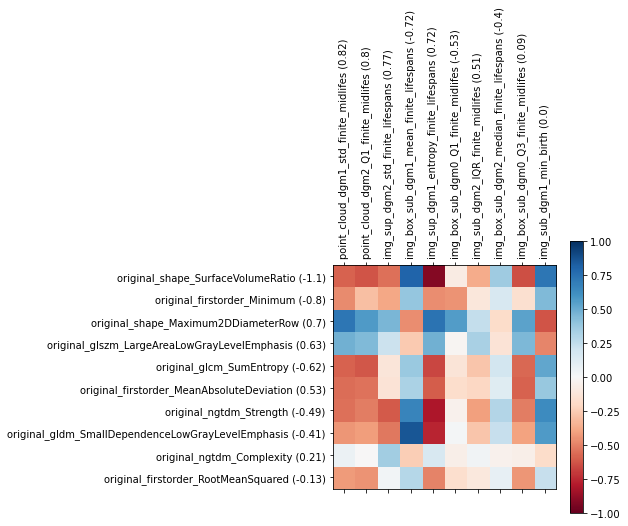

```python
I, y = get_patients_with_outcome(with_contrast, class0, class1)
model_rad = pipe_rad.fit(X=X_rad.loc[I,], y=y)
model_top = pipe_top.fit(X=X_top.loc[I,], y=y)
plot_features(I, model_rad, model_top)
```

#### Images without contrast (SF + PA)

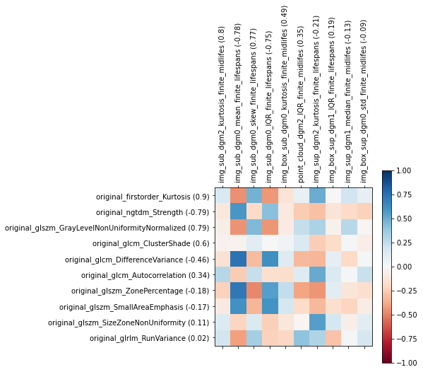

```python
I, y = get_patients_with_outcome(without_contrast, class0, class1)
model_rad = pipe_rad.fit(X=X_rad.loc[I,], y=y)
model_top = pipe_top.fit(X=X_top.loc[I,], y=y)
plot_features(I, model_rad, model_top)
```

### Comparing features for Small vs. Non-small classification

We analyze the selected features for **'small cell'** vs. **'non-small cell'** class prediction.

```python
class0 = ["Small cell lung cancer"]
class1 = ["Non-small cell lung cancer", "Adenocarcinoma", "Squamous cell carcinoma"]
```

#### Images with contrast (SF + PA)

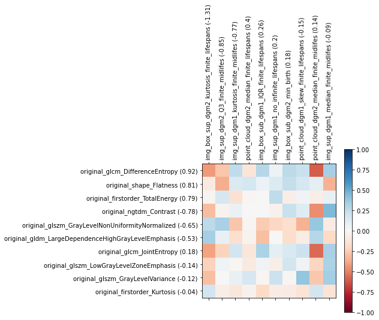

```python
I, y = get_patients_with_outcome(with_contrast, class0, class1)
model_rad = pipe_rad.fit(X=X_rad.loc[I,], y=y)
model_top = pipe_top.fit(X=X_top.loc[I,], y=y)
plot_features(I, model_rad, model_top)
```

#### Images without contrast (SF + PA)

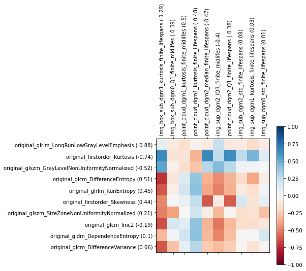

```python
I, y = get_patients_with_outcome(without_contrast, class0, class1)
model_rad = pipe_rad.fit(X=X_rad.loc[I,], y=y)
model_top = pipe_top.fit(X=X_top.loc[I,], y=y)
plot_features(I, model_rad, model_top)
```

### Comparing features for Adeno vs. Squamous classification

We analyze the selected features for **'adenocarcinoma'** vs. **'squamous cell carcinoma'** class prediction.

```python
class0 = ["Adenocarcinoma"]
class1 = ["Squamous cell carcinoma"]
```

#### Images with contrast (SF + PA)

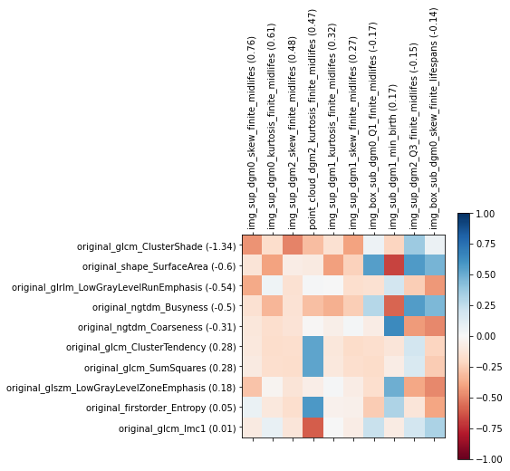

```python
I, y = get_patients_with_outcome(with_contrast, class0, class1)
model_rad = pipe_rad.fit(X=X_rad.loc[I,], y=y)
model_top = pipe_top.fit(X=X_top.loc[I,], y=y)
plot_features(I, model_rad, model_top)
```

#### Images without contrast (SF + PA)

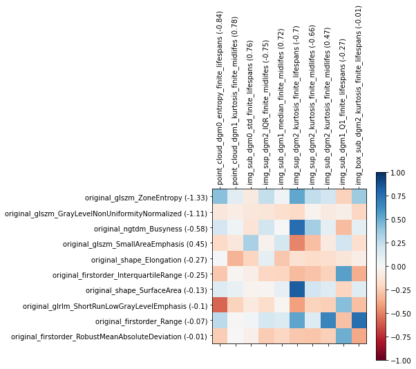

```python
I, y = get_patients_with_outcome(without_contrast, class0, class1)
model_rad = pipe_rad.fit(X=X_rad.loc[I,], y=y)
model_top = pipe_top.fit(X=X_top.loc[I,], y=y)
plot_features(I, model_rad, model_top)
```